# passerella quality control

Hannah Som

2/22/2023

```r
library(gridExtra)
library(knitr)
library(ggplot2)
library(fastqcr)
#must run this if fastqc is not already installed locally
fastqc_install()
```

```r
###ONLY THIS CHUNK REQUIRES MODIFICATION###
###assign your directory locations here:

#specify full path to directory containing a .fastq.gz file for each sample
fq.dir<-"/home/h690s403/work/rad.project/fastq"
#specify full path to the output directory where you want
qc.dir<-"/home/h690s403/work/rad.project/qc"
```

```r
#run fastqc on all .fastq.gz files, through r
#This only needs to be run once, if only tweaking downstream visualizations, you can comment out this step
fastqc(fq.dir = fq.dir, # FASTQ files directory
       qc.dir = qc.dir, # Results directory
       threads = 4      # Number of threads
       )
```

```r
# List of files in the output directory to ensure fastqc worked
list.files(qc.dir)
```

[1] “fastqcr.Rmd” “jobscript.sh”  
[3] “P_iliaca_119300_fastqc.html” “P_iliaca_119300_fastqc.zip” [5] “P_iliaca_119384_fastqc.html” “P_iliaca_119384_fastqc.zip” [7] “P_iliaca_119875_fastqc.html” “P_iliaca_119875_fastqc.zip” [9] “P_iliaca_119926_fastqc.html” “P_iliaca_119926_fastqc.zip” [11] “P_iliaca_14936_fastqc.html” “P_iliaca_14936_fastqc.zip”  
[13] “P_iliaca_20392_fastqc.html” “P_iliaca_20392_fastqc.zip”  
[15] “P_iliaca_27545_fastqc.html” “P_iliaca_27545_fastqc.zip”  
[17] “P_iliaca_30340_fastqc.html” “P_iliaca_30340_fastqc.zip”  
[19] “P_iliaca_30343_fastqc.html” “P_iliaca_30343_fastqc.zip”  
[21] “P_iliaca_31497_fastqc.html” “P_iliaca_31497_fastqc.zip”  
[23] “P_iliaca_34095_fastqc.html” “P_iliaca_34095_fastqc.zip”  
[25] “P_iliaca_34099_fastqc.html” “P_iliaca_34099_fastqc.zip”  
[27] “P_iliaca_34110_fastqc.html” “P_iliaca_34110_fastqc.zip”  
[29] “P_iliaca_34528_fastqc.html” “P_iliaca_34528_fastqc.zip”  
[31] “P_iliaca_36901_fastqc.html” “P_iliaca_36901_fastqc.zip”  
[33] “P_iliaca_37204_fastqc.html” “P_iliaca_37204_fastqc.zip”  
[35] “P_iliaca_37207_fastqc.html” “P_iliaca_37207_fastqc.zip”  
[37] “P_iliaca_37210_fastqc.html” “P_iliaca_37210_fastqc.zip”  
[39] “P_iliaca_37506_fastqc.html” “P_iliaca_37506_fastqc.zip”  
[41] “P_iliaca_37508_fastqc.html” “P_iliaca_37508_fastqc.zip”  
[43] “P_iliaca_37552_fastqc.html” “P_iliaca_37552_fastqc.zip”  
[45] “P_iliaca_38225_fastqc.html” “P_iliaca_38225_fastqc.zip”  
[47] “P_iliaca_38230_fastqc.html” “P_iliaca_38230_fastqc.zip”  
[49] “P_iliaca_38815_fastqc.html” “P_iliaca_38815_fastqc.zip”  
[51] “P_iliaca_38937_fastqc.html” “P_iliaca_38937_fastqc.zip”  
[53] “P_iliaca_40396_fastqc.html” “P_iliaca_40396_fastqc.zip”  
[55] “P_iliaca_40401_fastqc.html” “P_iliaca_40401_fastqc.zip”  
[57] “P_iliaca_40407_fastqc.html” “P_iliaca_40407_fastqc.zip”  
[59] “P_iliaca_41097_fastqc.html” “P_iliaca_41097_fastqc.zip”  
[61] “P_iliaca_42685_fastqc.html” “P_iliaca_42685_fastqc.zip”  
[63] “P_iliaca_44466_fastqc.html” “P_iliaca_44466_fastqc.zip”  
[65] “P_iliaca_80673_fastqc.html” “P_iliaca_80673_fastqc.zip”  
[67] “P_iliaca_80686_fastqc.html” “P_iliaca_80686_fastqc.zip”  
[69] “S_arborea_35787_fastqc.html” “S_arborea_35787_fastqc.zip” [71] “slurm-42764451.out” “slurm-42764571.out”  
[73] “Z_querula_26548_fastqc.html” “Z_querula_26548_fastqc.zip”

```r
#create a character vector where each value is the full path to the .zip created by fastqc() for a given sample
samps<-list.files(qc.dir, full.names = T, pattern = "*.zip")

#plot qc test results for each sample
for (i in samps){
  #read info for given sample from the .zip file generated in the previous step
  samp.info <- qc_read(i)
  #open blank list to hold qc visualizations for the given sample
  plot<-list()
  #do qc for the given sample
  plot[[1]]<-qc_plot(samp.info, "Basic statistics")
  plot[[2]]<-qc_plot(samp.info, "Per sequence quality scores")
  plot[[3]]<-qc_plot(samp.info, "Sequence duplication levels")
  #visualize tables
  print(paste0("QC results for sample ", gsub(".*/", "", i)))

  cat('\n')

  print(kable(plot[[1]]))

  cat('\n')

  #visualize plots
  grid.arrange(plot[[2]],plot[[3]],
               ncol=2)

  #clear plot to hold info for next sample
  rm(plot)
}
```

[1] “QC results for sample P_iliaca_119300_fastqc.zip”

| Measure | Value |
| --- | --- |
| Filename | P_iliaca_119300.fq |
| File type | Conventional base calls |
| Encoding | Sanger / Illumina 1.9 |
| Total Sequences | 2696625 |
| Sequences flagged as poor quality | 0 |
| Sequence length | 95 |
| %GC | 37 |

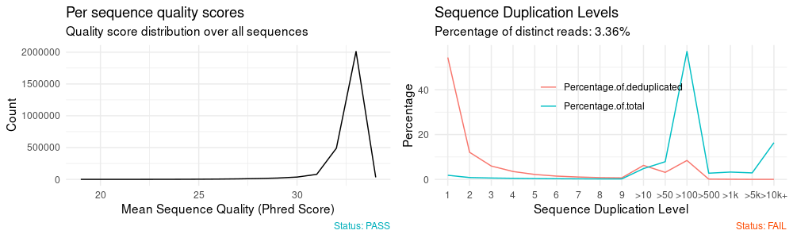

[1] “QC results for sample P_iliaca_119384_fastqc.zip”

| Measure | Value |
| --- | --- |
| Filename | P_iliaca_119384.fq |
| File type | Conventional base calls |
| Encoding | Sanger / Illumina 1.9 |
| Total Sequences | 556561 |
| Sequences flagged as poor quality | 0 |
| Sequence length | 95 |
| %GC | 38 |

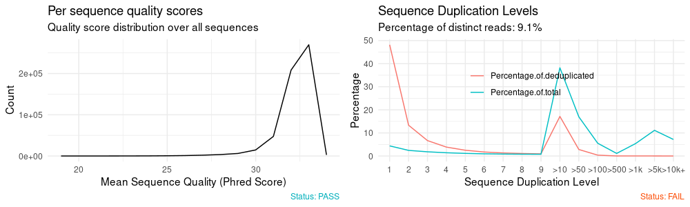

[1] “QC results for sample P_iliaca_119875_fastqc.zip”

| Measure | Value |
| --- | --- |
| Filename | P_iliaca_119875.fq |
| File type | Conventional base calls |
| Encoding | Sanger / Illumina 1.9 |
| Total Sequences | 93014 |
| Sequences flagged as poor quality | 0 |
| Sequence length | 95 |
| %GC | 38 |

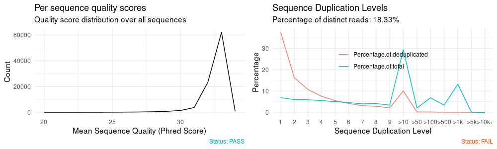

[1] “QC results for sample P_iliaca_119926_fastqc.zip”

| Measure | Value |
| --- | --- |
| Filename | P_iliaca_119926.fq |
| File type | Conventional base calls |
| Encoding | Sanger / Illumina 1.9 |
| Total Sequences | 1550233 |
| Sequences flagged as poor quality | 0 |
| Sequence length | 95 |
| %GC | 37 |

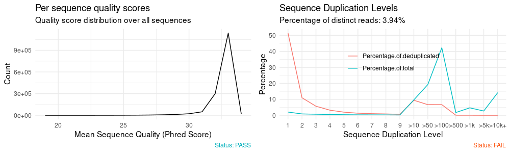

[1] “QC results for sample P_iliaca_14936_fastqc.zip”

| Measure | Value |
| --- | --- |
| Filename | P_iliaca_14936.fq |
| File type | Conventional base calls |
| Encoding | Sanger / Illumina 1.9 |
| Total Sequences | 126777 |
| Sequences flagged as poor quality | 0 |
| Sequence length | 95 |
| %GC | 36 |

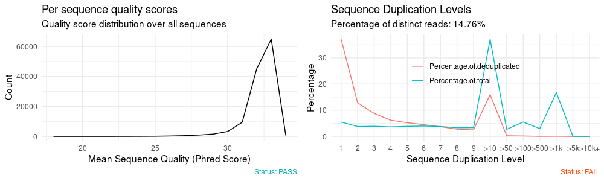

[1] “QC results for sample P_iliaca_20392_fastqc.zip”

| Measure | Value |
| --- | --- |
| Filename | P_iliaca_20392.fq |
| File type | Conventional base calls |
| Encoding | Sanger / Illumina 1.9 |
| Total Sequences | 972703 |
| Sequences flagged as poor quality | 0 |
| Sequence length | 95 |
| %GC | 38 |

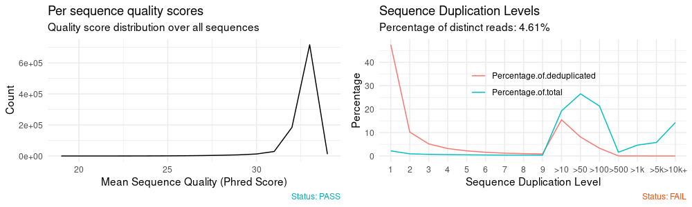

[1] “QC results for sample P_iliaca_27545_fastqc.zip”

| Measure | Value |
| --- | --- |
| Filename | P_iliaca_27545.fq |
| File type | Conventional base calls |
| Encoding | Sanger / Illumina 1.9 |
| Total Sequences | 23465 |
| Sequences flagged as poor quality | 0 |
| Sequence length | 95 |
| %GC | 38 |

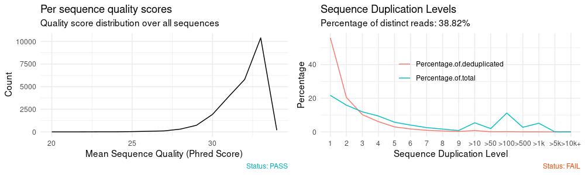

[1] “QC results for sample P_iliaca_30340_fastqc.zip”

| Measure | Value |
| --- | --- |
| Filename | P_iliaca_30340.fq |
| File type | Conventional base calls |
| Encoding | Sanger / Illumina 1.9 |
| Total Sequences | 310991 |
| Sequences flagged as poor quality | 0 |
| Sequence length | 95 |
| %GC | 36 |

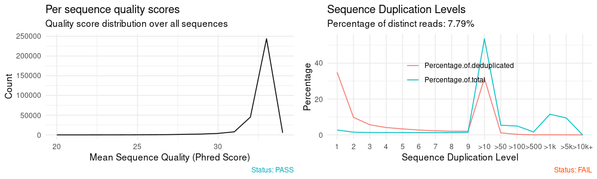

[1] “QC results for sample P_iliaca_30343_fastqc.zip”

| Measure | Value |
| --- | --- |
| Filename | P_iliaca_30343.fq |
| File type | Conventional base calls |
| Encoding | Sanger / Illumina 1.9 |
| Total Sequences | 3152635 |
| Sequences flagged as poor quality | 0 |
| Sequence length | 95 |
| %GC | 37 |

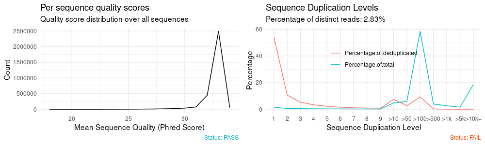

[1] “QC results for sample P_iliaca_31497_fastqc.zip”

| Measure | Value |
| --- | --- |
| Filename | P_iliaca_31497.fq |
| File type | Conventional base calls |
| Encoding | Sanger / Illumina 1.9 |
| Total Sequences | 2132136 |
| Sequences flagged as poor quality | 0 |
| Sequence length | 95 |
| %GC | 37 |

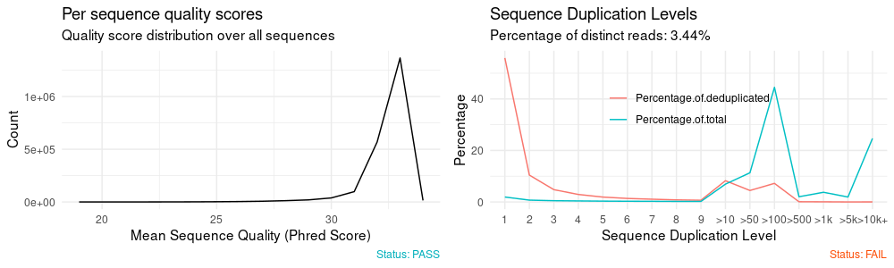

[1] “QC results for sample P_iliaca_34095_fastqc.zip”

| Measure | Value |
| --- | --- |
| Filename | P_iliaca_34095.fq |
| File type | Conventional base calls |
| Encoding | Sanger / Illumina 1.9 |
| Total Sequences | 4296206 |
| Sequences flagged as poor quality | 0 |
| Sequence length | 95 |
| %GC | 37 |

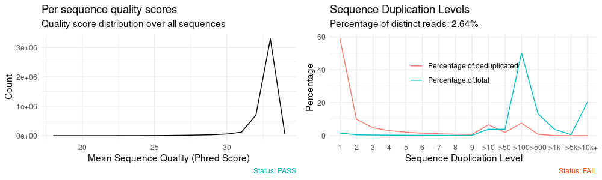

[1] “QC results for sample P_iliaca_34099_fastqc.zip”

| Measure | Value |
| --- | --- |
| Filename | P_iliaca_34099.fq |
| File type | Conventional base calls |
| Encoding | Sanger / Illumina 1.9 |
| Total Sequences | 2313352 |
| Sequences flagged as poor quality | 0 |
| Sequence length | 95 |
| %GC | 37 |

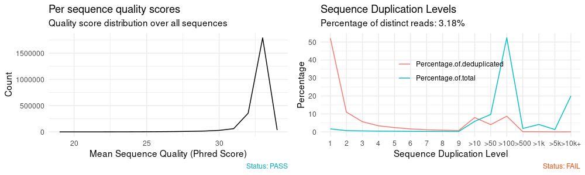

[1] “QC results for sample P_iliaca_34110_fastqc.zip”

| Measure | Value |
| --- | --- |
| Filename | P_iliaca_34110.fq |
| File type | Conventional base calls |
| Encoding | Sanger / Illumina 1.9 |
| Total Sequences | 917283 |
| Sequences flagged as poor quality | 0 |
| Sequence length | 95 |
| %GC | 37 |

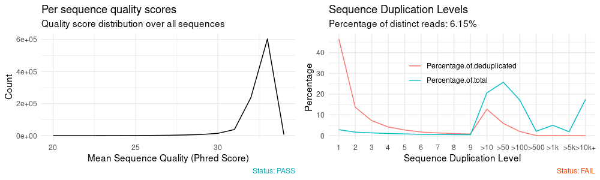

[1] “QC results for sample P_iliaca_34528_fastqc.zip”

| Measure | Value |
| --- | --- |
| Filename | P_iliaca_34528.fq |
| File type | Conventional base calls |
| Encoding | Sanger / Illumina 1.9 |
| Total Sequences | 83981 |
| Sequences flagged as poor quality | 0 |
| Sequence length | 95 |
| %GC | 38 |

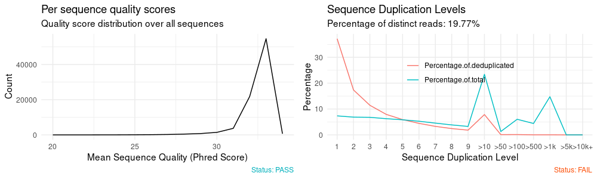

[1] “QC results for sample P_iliaca_36901_fastqc.zip”

| Measure | Value |
| --- | --- |
| Filename | P_iliaca_36901.fq |
| File type | Conventional base calls |
| Encoding | Sanger / Illumina 1.9 |
| Total Sequences | 835004 |
| Sequences flagged as poor quality | 0 |
| Sequence length | 95 |
| %GC | 37 |

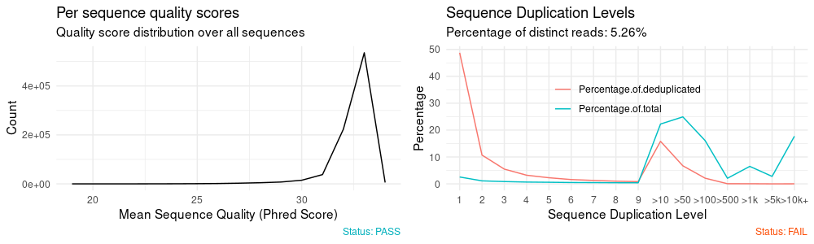

[1] “QC results for sample P_iliaca_37204_fastqc.zip”

| Measure | Value |
| --- | --- |
| Filename | P_iliaca_37204.fq |
| File type | Conventional base calls |
| Encoding | Sanger / Illumina 1.9 |
| Total Sequences | 1656767 |
| Sequences flagged as poor quality | 0 |
| Sequence length | 95 |
| %GC | 37 |

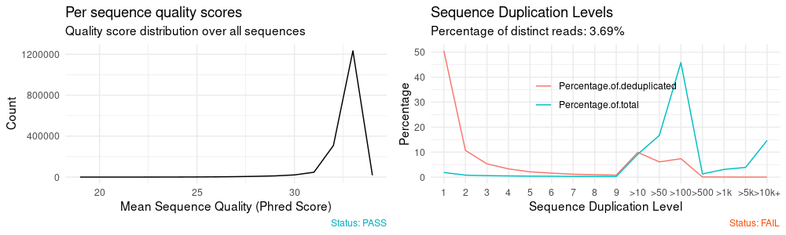

[1] “QC results for sample P_iliaca_37207_fastqc.zip”

| Measure | Value |
| --- | --- |
| Filename | P_iliaca_37207.fq |
| File type | Conventional base calls |
| Encoding | Sanger / Illumina 1.9 |
| Total Sequences | 1464177 |
| Sequences flagged as poor quality | 0 |
| Sequence length | 95 |
| %GC | 37 |

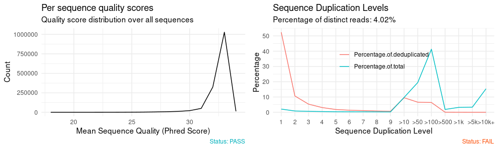

[1] “QC results for sample P_iliaca_37210_fastqc.zip”

| Measure | Value |
| --- | --- |
| Filename | P_iliaca_37210.fq |
| File type | Conventional base calls |
| Encoding | Sanger / Illumina 1.9 |
| Total Sequences | 523259 |
| Sequences flagged as poor quality | 0 |
| Sequence length | 95 |
| %GC | 38 |

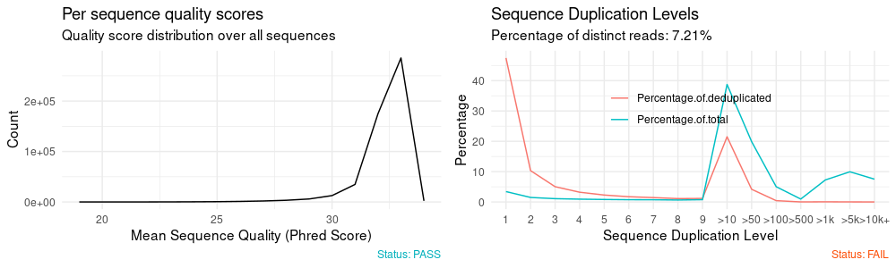

[1] “QC results for sample P_iliaca_37506_fastqc.zip”

| Measure | Value |
| --- | --- |
| Filename | P_iliaca_37506.fq |
| File type | Conventional base calls |
| Encoding | Sanger / Illumina 1.9 |
| Total Sequences | 153797 |
| Sequences flagged as poor quality | 0 |
| Sequence length | 95 |
| %GC | 38 |

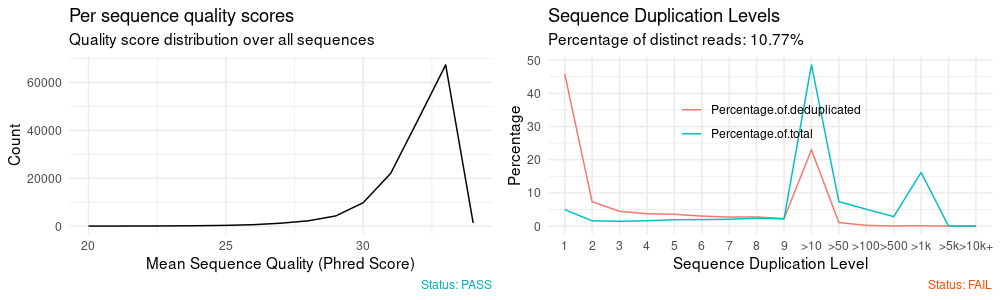

[1] “QC results for sample P_iliaca_37508_fastqc.zip”

| Measure | Value |
| --- | --- |
| Filename | P_iliaca_37508.fq |
| File type | Conventional base calls |
| Encoding | Sanger / Illumina 1.9 |
| Total Sequences | 38512 |
| Sequences flagged as poor quality | 0 |
| Sequence length | 95 |
| %GC | 37 |

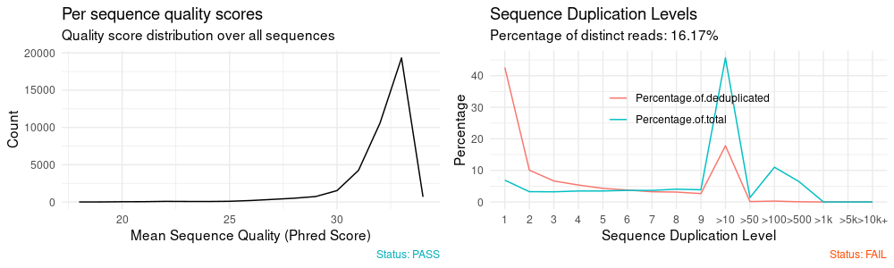

[1] “QC results for sample P_iliaca_37552_fastqc.zip”

| Measure | Value |
| --- | --- |
| Filename | P_iliaca_37552.fq |
| File type | Conventional base calls |
| Encoding | Sanger / Illumina 1.9 |
| Total Sequences | 4169 |
| Sequences flagged as poor quality | 0 |
| Sequence length | 95 |
| %GC | 36 |

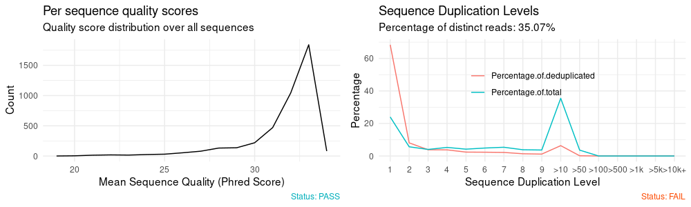

[1] “QC results for sample P_iliaca_38225_fastqc.zip”

| Measure | Value |
| --- | --- |
| Filename | P_iliaca_38225.fq |
| File type | Conventional base calls |
| Encoding | Sanger / Illumina 1.9 |
| Total Sequences | 448299 |
| Sequences flagged as poor quality | 0 |
| Sequence length | 95 |
| %GC | 36 |

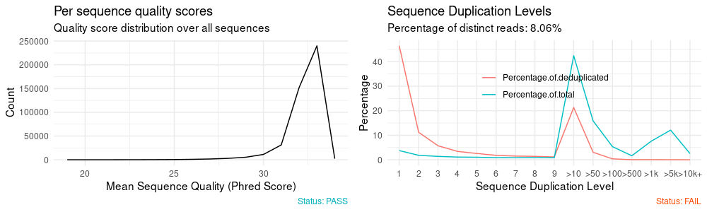

[1] “QC results for sample P_iliaca_38230_fastqc.zip”

| Measure | Value |
| --- | --- |
| Filename | P_iliaca_38230.fq |
| File type | Conventional base calls |
| Encoding | Sanger / Illumina 1.9 |
| Total Sequences | 572055 |
| Sequences flagged as poor quality | 0 |
| Sequence length | 95 |
| %GC | 37 |

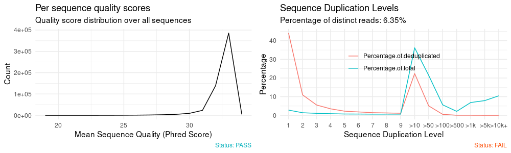

[1] “QC results for sample P_iliaca_38815_fastqc.zip”

| Measure | Value |
| --- | --- |
| Filename | P_iliaca_38815.fq |
| File type | Conventional base calls |
| Encoding | Sanger / Illumina 1.9 |
| Total Sequences | 2234610 |
| Sequences flagged as poor quality | 0 |
| Sequence length | 95 |
| %GC | 37 |

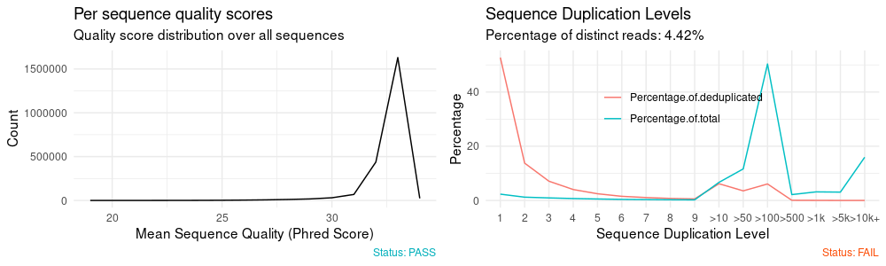

[1] “QC results for sample P_iliaca_38937_fastqc.zip”

| Measure | Value |
| --- | --- |
| Filename | P_iliaca_38937.fq |
| File type | Conventional base calls |
| Encoding | Sanger / Illumina 1.9 |
| Total Sequences | 724799 |
| Sequences flagged as poor quality | 0 |
| Sequence length | 95 |
| %GC | 37 |

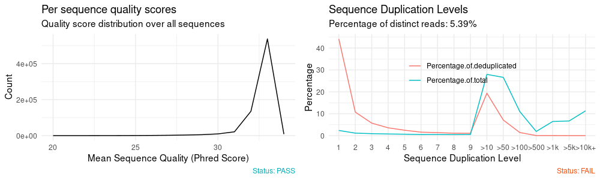

[1] “QC results for sample P_iliaca_40396_fastqc.zip”

| Measure | Value |
| --- | --- |
| Filename | P_iliaca_40396.fq |
| File type | Conventional base calls |
| Encoding | Sanger / Illumina 1.9 |
| Total Sequences | 826920 |
| Sequences flagged as poor quality | 0 |
| Sequence length | 95 |
| %GC | 37 |

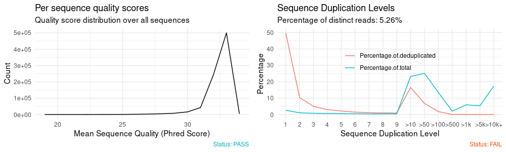

[1] “QC results for sample P_iliaca_40401_fastqc.zip”

| Measure | Value |
| --- | --- |
| Filename | P_iliaca_40401.fq |
| File type | Conventional base calls |
| Encoding | Sanger / Illumina 1.9 |
| Total Sequences | 211314 |
| Sequences flagged as poor quality | 0 |
| Sequence length | 95 |
| %GC | 37 |

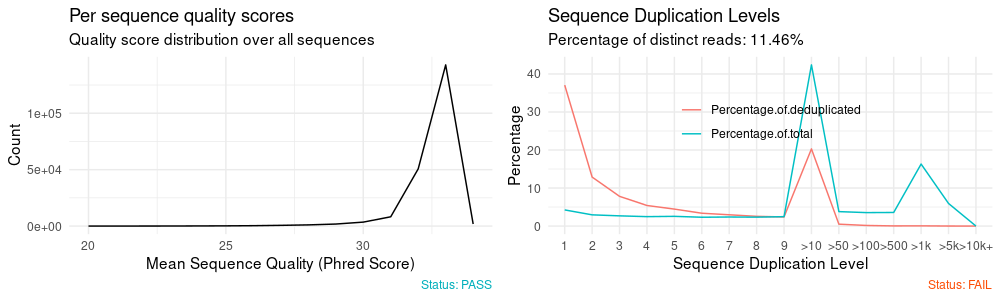

[1] “QC results for sample P_iliaca_40407_fastqc.zip”

| Measure | Value |
| --- | --- |
| Filename | P_iliaca_40407.fq |
| File type | Conventional base calls |
| Encoding | Sanger / Illumina 1.9 |
| Total Sequences | 2781624 |
| Sequences flagged as poor quality | 0 |
| Sequence length | 95 |
| %GC | 37 |

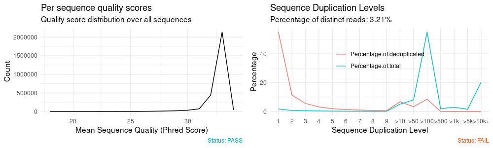

[1] “QC results for sample P_iliaca_41097_fastqc.zip”

| Measure | Value |
| --- | --- |
| Filename | P_iliaca_41097.fq |
| File type | Conventional base calls |
| Encoding | Sanger / Illumina 1.9 |
| Total Sequences | 4339464 |
| Sequences flagged as poor quality | 0 |
| Sequence length | 95 |
| %GC | 37 |